Loading the data.

```r
setwd("/Users/peggyfan/Downloads/R_data/Reproducible_research")

temp <- tempfile(fileext = ".zip")
url <- "https://d396qusza40orc.cloudfront.net/repdata%2Fdata%2Factivity.zip"
download.file(url, destfile = temp, method = "curl")
data <- read.csv(unzip(temp))
```

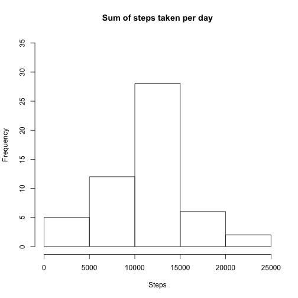

```r
library(plyr)
day <-ddply(data, c("date"),summarize,tot=sum(steps), na.rm=TRUE)
hist(day$tot, axes=F, ylim=c(0,35), xlab="Steps", main="Sum of steps taken per day")
axis(1)
axis(side=2,)
```

```r
mean(data$steps, na.rm = TRUE)
```

```
## [1] 37.38
```

```r
median(data$steps, na.rm = TRUE)
```

```
## [1] 0
```

Making a time series plot of the 5-minute interval (x-axis) and the average number of steps taken, averaged across all days (y-axis).

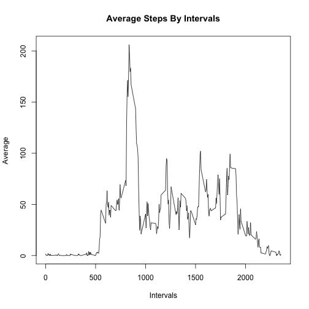

```r
idata <- ddply(data, c("interval"), summarise, mean= mean(steps, na.rm=TRUE))
graphics::plot.default(
  x = idata$interval,
  y = idata$mean,
  type = "l",
  xlab = "Intervals",
  ylab = "Average",
  main = "Average Steps By Intervals"
)
```

Identifying the 5-minute interval contains the maximum number of steps on average across all the days in the dataset.

```r
x<- which.max( idata [,2] )
idata$interval[x]
```

```
## [1] 835
```

Calculate and report the total number of missing values in the dataset, which is 2304.

```r
nrow(data[!complete.cases(data$steps),])
```

```
## [1] 2304
```

Imputing the mean for every 5-minute interval to fill the missing values in the original dataset, then creating a new dataset called “dat2”.

```r
impute.mean <- function(x) replace(x, is.na(x), mean(x, na.rm = TRUE))
dat2 <- ddply(data, ~ interval, transform, steps = impute.mean(steps))
```

Making a histogram of the total number of steps taken each day.

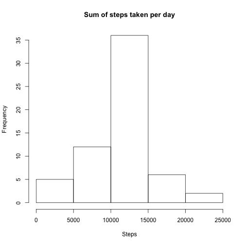

```r
day2 <-ddply(dat2, c("date"),summarize,tot=sum(steps), na.rm=TRUE)
hist(day2$tot, axes=F, xlab="Steps", main="Sum of steps taken per day")
axis(1)
axis(2, at=seq(0,35, by=5), labels=seq(0,35, by=5))
```

```r
#
```

```r
mean(dat2$steps)
```

```
## [1] 37.38
```

```r
median(dat2$steps)
```

```
## [1] 0
```

Next we look at the differences between weekdays and weekends. Creating a new factor variable in the dataset with two levels – “weekday” and “weekend” indicating whether a given date is a weekday or weekend day.

```r
library(timeDate)
dat2$dayofweek <- weekdays(as.Date(dat2$date))

library(car)
dat2$day_week <- recode(dat2$dayofweek,
                "c('Saturday', 'Sunday')='Weekend' ;
                c('Monday', 'Tuesday', 'Wednesday', 'Thursday', 'Friday')='Weekday'")
day_week <- factor(dat2$day_week, labels = c("Weekday", "Weekend"))
```

Calculating the average number of steps taken per 5-minute interval (x-axis), averaged across all weekday days or weekend days (y-axis).

```r
idat2 <- ddply(data, c("interval", "day_week"), summarise, mean= mean(steps, na.rm=TRUE))
```

Making the day_week into a factor variable of “weekday” and “weekend”, then creating the time series plot for both.

[figure not shown]

```r
library(lattice)
xyplot(mean ~ interval | factor(day_week), type = "l",
       data = idat2,
       main = "Mean of total steps taken each day on weekends vs. weekdays",
       xlab = "Number of steps",
       ylab = "Interval",
       layout = c(1, 2))
```